# Chapter 2.小世界与大世界

在统计研究中，小世界和大世界可以类比统计中的模型与现实。我们可以基于我们对于现实的认识来构造一个模型，这个模型可以帮助我们更好地认识现实，但是值得注意的是在模型中行得通的结论在现实中可能是错误的。

而贝叶斯模型有着独到的优势，它能够更充分地利用模型的信息，而在本章中我们也会重点去认识和学习贝叶斯模型。

## 2.1 分叉数据的花园

### 2.1.1 计算可能性

考虑下面的这种情况，布袋中有四个或蓝或白的球（除颜色外完全相同），则这四个球的组合有以下五种推测：

(1)[白白白白]；

(2)[蓝白白白]；

(3)[蓝蓝白白]；

(4)[蓝蓝蓝白]；

(5)[蓝蓝蓝蓝]；

现在我们进行有放回的摸球，摸球的结果依次为[蓝 白 蓝]，则我们有如下图所示的分析过程：

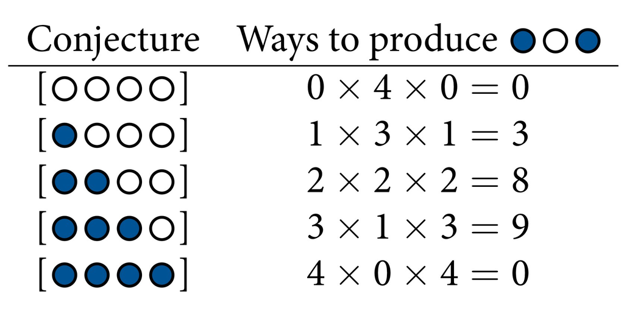

以第二个推测为例，第一个摸出的球是蓝球，则只有摸出蓝球1这一可能的路径，第二个摸出的球是白球，则有白球1、白球2和白球3这三条可能的路径，第三个摸出的是蓝球，则也只有摸出蓝球1这一可能的路径。综上，共有$1*3*1=3$条可能的路径。由于[蓝蓝蓝白]对应的可能的路径最多，我们认为这个推测是更有可能的

### 2.1.2 利用先验信息

假设在2.1.1的基础上，我们又进行了一次摸球，结果为蓝球，那么就可以将2.1.1中得到的信息作为先验信息，来帮助我们判断各个推测是更有可能的，如下图所示：

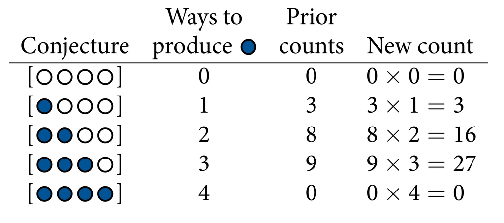

类比2.1.1的推理过程，由于[蓝蓝蓝白]对应的可能的路径最多，我们认为这个推测是更有可能的。

### 2.1.3 从计数到概率

$$\begin{aligned}
&观察到[蓝白蓝]的情况下[蓝白白白]成立的可能性\\
&~~~~~~~~~~~~~~~~~~~~~~~~~~~~~~~~~~~~~~~~~\propto\\
&在[蓝白白白]的假设下得到[蓝白蓝]的方式数目\\
&~~~~~~~~~~~~~~~~~~~~~~~~~~~~~~~~~~~~~~~~~\times\\
&~~~~~~~~~~~~~~~~~~~~~~[蓝白白白]的先验可能性\\
\end{aligned}$$

将袋中蓝色大理石的比例定义为p，对于【蓝白白白】的情况，$p=\frac{1}{4}=0.25$，将观测定义为$D_{new}$=[蓝白蓝]，这样一来就有如下的数学表达式：

$$观测到D_{new}情况下p成立的可能性=在p的假设下得到D_{new}的方式数目*
p的先验概率$$

上面的表达式意味着对于任何的p值，我们认为其成立的可能性正比于在该p取值的情况下路径花园对应的路径的数目。

最后，我们将计算出的这些可能性标准化到[0,1]区间上得到相应的概率值，标准化后，所有假设的可能性取值相加为1。

$$观测到D_{new}情况下p成立的可能性=\frac{在p的假设下得到D_{new}的路径数目*
p的先验概率}{所有p对应的乘积之和}$$

我们用定义的p和’可能性’更新2.1.1中的表格如下所示：

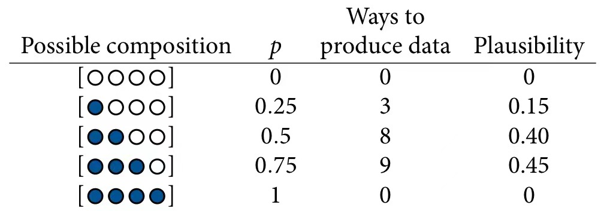

**注：比如 0.15 = (3 * 0.2) / (0 * 0.2 + 3 * 0.2 + 8 * 0.2 + 9 * 0.2 + 0 * 0.2 )，其中，0.2表示蓝色大理石的比例p为0.25时的先验概率，由于这里假设所有情况都是一样的，所以每种情况的先验概率都是0.2**

以上所述每一步计算都存在对应的应用概率理论的定义：

(1)假定蓝色大理石的比例P通常称为参数值。

(2)每个p的取值对应的产生数据的路径数目通常称为似然值。

(3)关于p的先验可能性通常称为先验概率。

(4)在特定p取值情况下，根据样本观测更新后的可能性取值称为后验概率。

## 2.2 建立模型

假设你手中有一个地球，你想估计地球被陆地和水覆盖的比例分别是多少。你进行了下面的实验，将地球抛在空中，然后接到手中，记录地球最上面的那一点是陆地(L)还是水(W)。你把这个实验重复了9次，得到了如下结果：

$$W ~~L ~~ W ~~ W ~ ~W ~
~L ~~W ~~L ~~ W$$

### 2.2.1 数据的故事

贝叶斯数据分析往往意味着生成一个关于当前数据是怎么生成的的故事。即我们是怎样完成一次试验的，怎么收集我们观测数据的。比如在我们上述例子中，我们做出了以下假设：

（1）地球实际被水覆盖的比例为p；

（2）每一次投掷试验都有p的可能性生成一个观测water(w),有1-p的可能性生成一个观测land(L)；

（3）每次投掷都是独立的。

### 2.2.1 贝叶斯更新

我们的目的是根据现有的观测来推测地球表面被水覆盖的比例。Bayes模型开始于一系列的先验概率，然后根据我们实时观测结果来产生后验概率，后验概率又可以作为下一次实验的先验概率，以此进行，即贝叶斯更新。

首先由于我们没有任何关于p的信息，因此我们暂时认为p服从0到1上的均匀分布，然后我们利用几个观测的结果依次对贝叶斯模型进行更新，结果如下图所示：

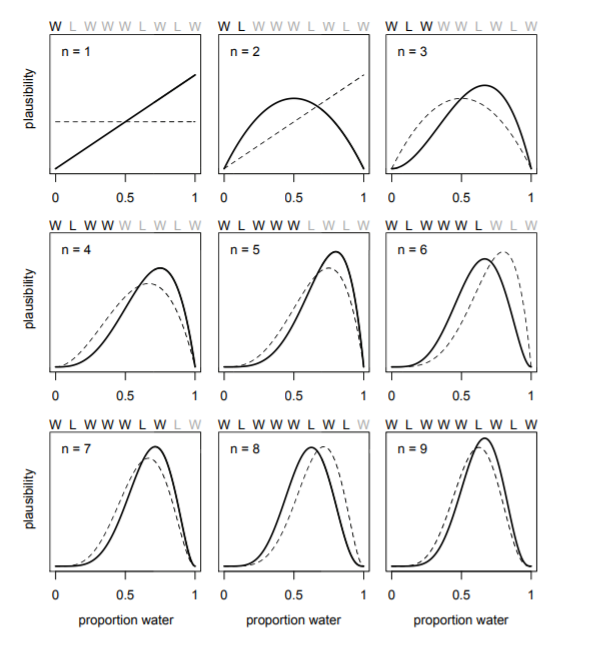

对于图上任一点，X轴坐标表示该点对应的p的取值，Y轴坐标则表示的是该点所取p值对应的可能性，虚线则表示本次试验的先验概率，实线则表示本次实验的后验概率，上一次试验的后验概率即本次试验的先验概率。值得注意是每一次W观测都将导致曲线右偏，L观测将导致曲线左偏。而曲线最高点高度不断上升意味着少部分p值对应的可能性随着样本的增加在不断上升。

注意：相较于非贝叶斯统计的良好表现往往建立在大样本的假设而言，贝叶斯统计对于任意大小的样本均有意义，但是贝叶斯统计依赖于初试可能性（先验概率），两种方法各有其特点。

### 2.2.3 评估

如果模型中对大世界的描述是准确的，那么Bayes推断通常是最优的解决方案。但是对模型结果的评价和核查依旧是不可缺少的。如果模型和现实存在很大差异，那么模型的适用性就应当让人怀疑。即便是模型和现实符合的很好，也至少需要注意下面两个原则。

（1）模型的确定性并不能保证模型是一个好模型。比如上面的例子，随着地球投掷次数增大，曲线范围会变得越来越窄，那么地球被水覆盖的比例变得确定性越来越高。但是，我们并不能保证这就是一个真实的情况，我们的推测都是建立在模型基础上的，我们不能保证选择的模型是一个好模型，换一个模型，可能得到不同的推论。比如，我们用的地球模型不能正确反映真实的海洋覆盖率，那么模型得到的确定性再高也没有意义。

（2）对模型进行检查评估是很重要的。在上面的例子中，9次试验的都是独立的，和试验顺序没有关系。所以不管你怎么投掷，只要是6次水3次陆地，最后的结果总是一样的。但是，如果试验之间不是独立的，那么就会得到完全不一致的结果。

## 2.3 模型的组成

### 2.3.1 变量

变量是就是一些可以取不同值的符号。本书中将变量分为可观测变量和不可观测变量（PARAMETRES即参数），例如上文中地球被水覆盖的比例p即为一个不可观测变量。我们可以通过可观测变量来推导不可观测变量。

### 2.3.2 一些定义

#### 2.3.2.1 可观测变量

似然函数（LIKELIHOOD）：指的是一个可观测变量的分布函数。

在上面掷地球的例子中，我们假设了每次实验都是独立的，同时每次投掷得到W的概率都相等，也就是一个我们了解的典型的二项分布模型。在这种情况下，地球被水覆盖的比例为p时，投掷n次地球，可以观测到w次海洋的概率为：

$$Pr(W|N,p)=\frac{N!}{W!(N-W)!}p^W(1-p)^{N-W}$$

在R语言中，可以通过dbinom函数来计算概率。

```r
dbinom(6, size = 9, prob = 0.5)
```

```
## [1] 0.1640625
```

#### 2.3.2.2 不可观测变量

我们赋予可观测变量的分布函数中也有属于分布函数自己的变量，在上面的二项分布中就是p。

在Bayes模型中，每一个需要估计的参数都要有一个先验概率（prior）。

在上面掷地球的例子中，前一个试验的后验概率变为了后一个试验的前验概率，但是最关键的问题在于第一个试验的前验概率从何而来？很多时候是以人的信念为先验概率(SUBJECTIVE BAYESIAN)，比如上面提到的例子中所有的先验概率都一样。这也是我们在没有任何先验信息可用的情况下，常常使用的策略。这种先验概率通常被认为是弱信息先验概率，不过依旧很有用，很多非Bayes统计模型也使用了类似的策略。

### 2.3.3 构造模型

还是以掷地球为例，本例中一共涉及到4个变量：N（抛掷的总次数），W（水朝上的次数），L（陆地朝上的次数），p （地球实际被水覆盖的比例，未知参数）。其中N=W+L。我们可以构造以下两个模型。
$$W\sim Binomial(N,p)$$
$$p\sim Uniform(0,1)$$
注意到此处我们给p赋予了一个从0到1均匀分布的先验概率，但这显然并不是一个好的选择。

## 2.4 运行模型

### 2.4.1 贝叶斯理论

对于每一个数据，似然函数，参数以及前验概率的独特组合而言，我们都可以得出一个独特的后验函数。以掷地球试验为例，后验概率实际上可以用以下表达式进行表示：
$$Pr(p|W,L)$$
要推导出这个公式，我们首先对条件概率公式和贝叶斯公式进行简单的复习。
$$Pr(W,L,p)=Pr(W,L|p)Pr(p)$$
$$Pr(W,L,p)=Pr(p|W,L)Pr(W,L)$$
$$Pr(W,L|p)*Pr(p)=Pr(p|W,L)Pr(W,L)$$
通过上面三个公式，我们可以推导出著名的贝叶斯公式，如下所示：
$$Pr(p|W,L)=\frac{Pr(W,L|p)Pr(p)}{Pr(W,L)}$$
将上述公式放在更一般的条件下，即可得到后验概率的推导公式：
$$后验=\frac{似然函数 \times
先验}{平均似然}$$
其中平均似然指的是利用先验对似然函数进行平均后的所得到的，可以用以下公式进行表示：
$$Pr(W,L)=E(Pr(W,L|p))=\int
Pr(W,L|p)Pr(r)dp$$
接下来看贝叶斯公式在掷地球实验中的实际应用，如下图所示：

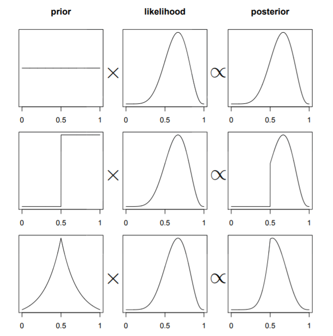

x轴表示的是地球上被水覆盖的比例p,y轴表示的是可能性，此处的似然函数是我们在上文中通过9次试验得到的，我们可以看到在似然函数相同，先验不同的情况下，我们得到的后验也有所差异。

### 2.4.2 数值模拟方法

对于电脑而言，它虽然不能理解贝叶斯理论的公式，但是会采用数值模拟的方法来对后验进行求解，主要有以下三种方法：

（1）网格逼近（Grid approximation）

（2）二项逼近（Quadratic approximation）

（3）马尔科夫链蒙特卡罗方法(MCMC)

接下来主要对三种方法进行介绍：

### 2.4.3 网格逼近

1.定义

对于每个参数取值p’,我们只需要计算后验概率，即将p’对应的先验概率乘以p’对应的似然函数值。在每个网格上取一个参数值计算相应的后验概率就能够大致逼近后验分布，这个过程就叫做网格逼近。

2.对模型进行网格逼近的步骤

1)定义网格。意味着需要用多个点来近似后验分布，然后将参数区域分成相应数目的网格选取参数值。

2)对每个参数值计算先验概率。

3)对每个参数值计算似然函数值。

4)将每个参数对应的先验概率乘以似然函数值得到没有标准化的后验概率。

5)最后通过除以所有后验概率取值的和对后验概率分布进行标准化。

以投掷球为例，用R代码实现以上5个步骤：

```r
#定义网格
p_grid<-seq(from=0,to=1,length.out=20) #生成从0-1之间间隔相同的20个数
head(p_grid)
```

```
## [1] 0.00000000 0.05263158 0.10526316 0.15789474 0.21052632 0.26315789
```

定义先验分布$Pr(p)$

```r
prior<-rep(1,20)#将1重复20遍
```

计算网格每个参数取值对应的似然函数$Pr(w|p)$

```r
likelihood<-dbinom(6,size=9,prob=p_grid)#在每次给定概率取值的情况下，投掷9次，观测到6次水面的概率
head(likelihood)
```

```
## [1] 0.000000e+00 1.518149e-06 8.185093e-05 7.772923e-04 3.598575e-03
## [6] 1.116095e-02
```

计算似然函数和先验概率的乘积$Pr(w|p)Pr(p)$

```r
unstd.posterior<-likelihood*prior
head(unstd.posterior)
```

```
## [1] 0.000000e+00 1.518149e-06 8.185093e-05 7.772923e-04 3.598575e-03
## [6] 1.116095e-02
```

对后验概率进行标准化，标准化后概率之和为1
$$Pr(p|w)=\frac{Pr(w|p)Pr(p)}{Pr(w)}$$

```r
posterior<-unstd.posterior/sum(unstd.posterior)
head(posterior)
```

```
## [1] 0.000000e+00 7.989837e-07 4.307717e-05 4.090797e-04 1.893887e-03
## [6] 5.873873e-03
```

3.绘制得到的后验分布

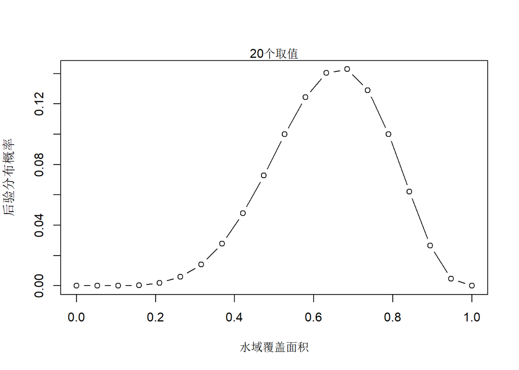

```r
plot(p_grid,posterior,type="b",xlab="水域覆盖面积",ylab="后验分布概率")
mtext("20个取值")
```

我们这儿只是使用了一个20个点的网格，你可以尝试使用不同大小的网格，网格越小，意味着你得到的结果越精确。

### 2.4.2 二项逼近（高斯逼近）

网格逼近有一个缺点，如果你的模型中有多个参数，那么你的计算量会成倍增长。比如有两个参数，每个都有100个网格，那么最终你要估计10000次。这个时候就体现出二项逼近的作用了。

一般情况下，后验概率的分布在分布的尖峰处会呈现出近正态分布。也就是说后验概率分布可以用正态分布来估计。我们知道正态分布很简单，只有两个参数就够了：位置参数（均值）和形状参数（方差）。正态分布类似抛物线，一个二次函数就可以描述，所以称之为平方估计。二项逼近准确度很高，同时对计算的要求又不像网格逼近或者MCMC那么高。

对模型进行二项逼近的步骤：

1)寻找后验众数。通常是通过最优算法寻找分布的”顶峰”。

2)找到后验分布的峰顶，估计峰顶的曲率。

```r
library(rethinking)
```

```r
# 构建模型
globe.qa <- map(
  alist(w ~ dbinom(9,p), # 二项分布的似然率
  p ~ dunif(0,1)), # 均一分布的先验概率
  data = list(w=6) # 观测到6次海洋
)

# 显示二项逼近的结果
precis(globe.qa)
```

```
##        mean        sd      5.5%     94.5%
## p 0.6666663 0.1571339 0.4155361 0.9177966
```

通过上面的平方估计，可以看到p=0.67，标准差为0.16，也就是后验概率分布的标准差，89%的分布区间为0.42-0.92。我们将得到的这个正态分布与实际的后验概率分布作比较如下：

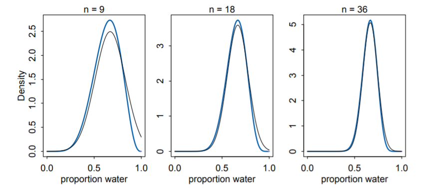

### 2.4.5 马尔科夫链蒙特卡罗方法

为什么要用马尔科夫链蒙特卡罗方法？对于参数量较大的模型而言。网格法的计算量非常大，耗费的时间过长；二项逼近容易出错（海森矩阵不正定），并且有时候后验分布的具体形式也不好表达，目标函数未知。

马尔科夫链蒙特卡罗方法通过模拟的方式对高维积分进行计算，进而使原本异常复杂的高维积分计算问题迎刃而解，使贝叶斯方法仅适用于解决简单低维问题的状况大有改观为贝叶斯方法的应用开辟了新的道路。但是它不是直接对后验分布进行模拟，而仅仅是从后验中抽取一些样本。本章中不会对该方法进行重点介绍，而会在第九章中结合实例详细说明，以下是用马尔科夫链蒙特卡罗方法模拟掷地球试验的代码：

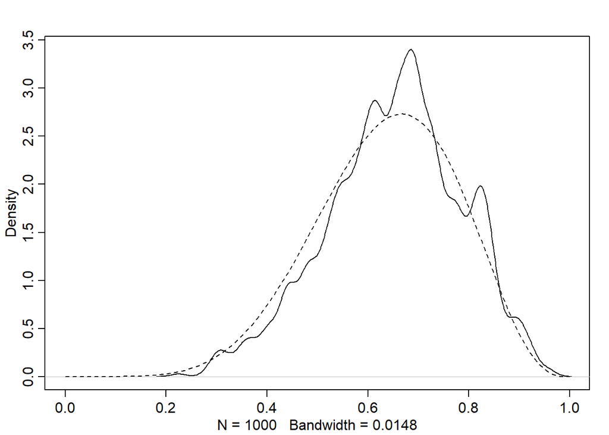

```r
library(rethinking)
n_samples <- 1000
p <- rep( NA , n_samples )
p[1] <- 0.5
W <- 6
L <- 3
for ( i in 2:n_samples ) {
p_new <- rnorm( 1 , p[i-1] , 0.1 )
if ( p_new < 0 ) p_new <- abs( p_new )
if ( p_new > 1 ) p_new <- 2 - p_new
q0 <- dbinom( W , W+L , p[i-1] )
q1 <- dbinom( W , W+L , p_new )
p[i] <- ifelse( runif(1) < q1/q0 , p_new , p[i-1] )
}#此处的p即是从后验中抽取的一些样本#
dens( p , xlim=c(0,1) )
curve( dbeta( x , W+1 , L+1 ) , lty=2 , add=TRUE )
```

```r
#可以看到我们得到的结果虽然比较奇怪，但仍然有效#
```

## 2.5 总结

贝叶斯推断的目标——>后验概率分布

后验概率——–> 介绍了基于现有数据的不同推测的可能性大小

贝叶斯模型——->由一系列变量及它们的分布信息组成

似然（也可称为数据的概率）——->在已知模型参数值的基础上，给出某个观测的可能性大小

先验——>在考虑数据的影响之前，给出参数每一个可能取值的可能性大小